# The Quiet Decline of Mental Health

Author

Ruchi

## The question

People carry real mental distress and still show up to work every day. We read “still functioning” as “fine.” I wanted to see what the national numbers actually say.

## What the data shows

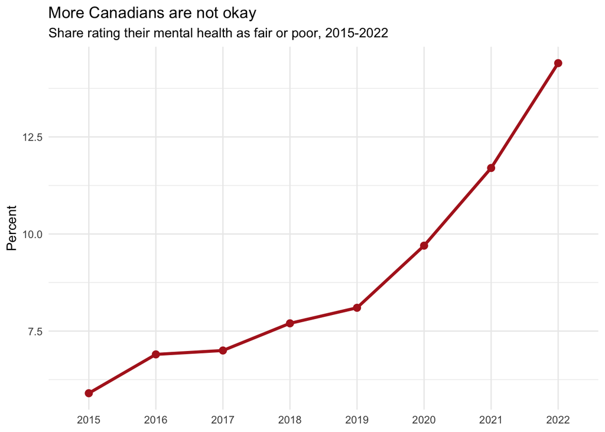

The share of Canadians rating their mental health as fair or poor more than doubled between 2015 and 2022, climbing every year and accelerating toward the end. This happened while the country kept working.

## What this shows and what it doesn’t

This is the national picture. It does not yet break the trend down by who is employed, or by occupation, so it points to the pattern without isolating working people specifically.

## Work Absence in Health Care: A Structural Pattern, Not Just a Pandemic Spike

Using Statistics Canada’s Work Absence Rates data (Table 14-10-0191), I examined how many workdays health care and social assistance workers lose per year compared to other sectors, and what’s actually driving that loss.

### Health care absence over time

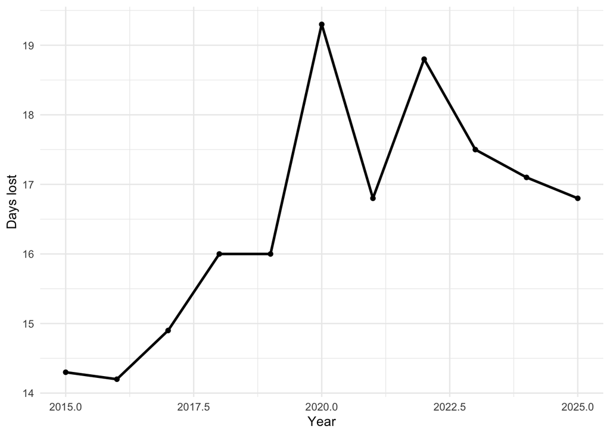

Figure 1: Days lost per worker per year, Health Care and Social Assistance, Canada, 2015–present

Health care workers lost 14 to 19 days per year over this period, with visible spikes in 2020 and 2022 followed by only partial recovery.

### How health care compares to the broader economy

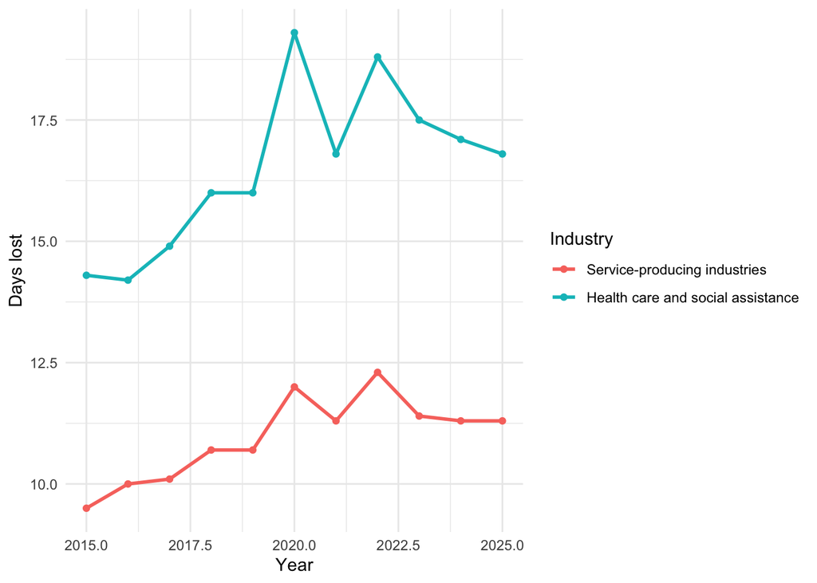

Figure 2: Health Care vs. All Service-Producing Industries

### What’s actually driving the gap: illness, not caregiving

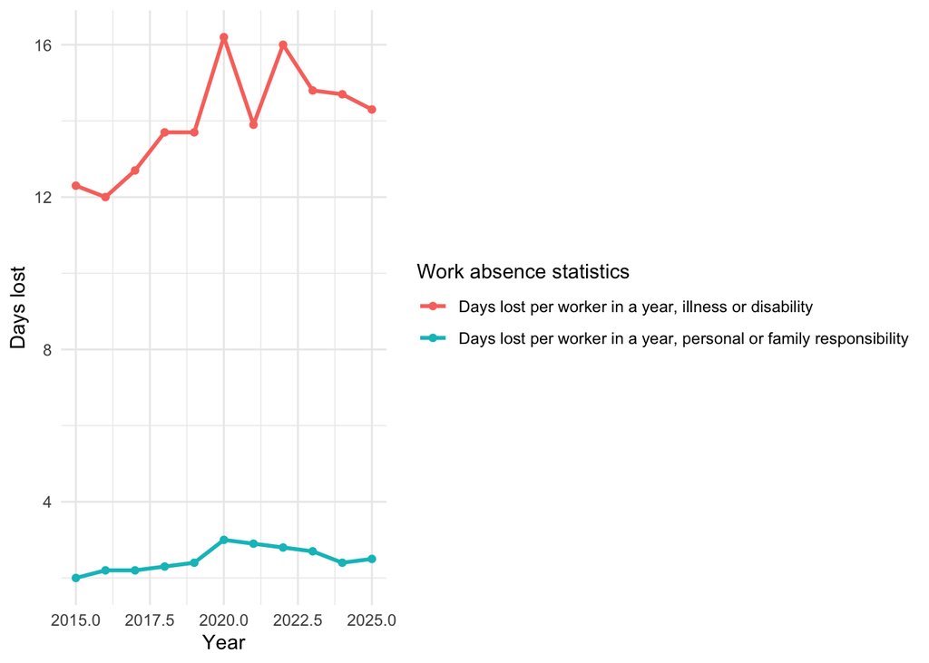

Figure 3: Health Care Absence, By Reason

### Takeaway

Health care and social assistance workers carry a persistently higher absence burden than the broader Canadian workforce, and that burden is driven by illness or disability rather than caregiving responsibilities. This points toward the occupational health cost of the work itself, high emotional demand, understaffing, and sustained patient-facing stress, rather than a work-life balance issue. It connects functional presence at work (simply showing up) to a separate, harder question: whether workers in high-demand roles are genuinely well, or working through conditions that eventually surface as time away from work entirely.